# Homework_6

Claire Kraft

2024-10-02

I DID NOT SUBMIT THIS HOMEWORK AS I DID NOT COMPLETE THE ASSIGNMENT. COMMITING THIS TO THE REPO FOR MIDTERM EXAM REVIEW PURPROSES. THE CODE RESULTS AND INTERPEATIONS ARE AFTER THE 2024-10-03 THURSDAY TA SESSION.

## Question 9.1

**Using the same crime data set uscrime.txt as in Question 8.2, apply Principal Component Analysis and then create a regression model using the first few principal components. Specify your new model in terms of the original variables (not the principal components), and compare its quality to that of your solution to Question 8.2. You can use the R function prcomp for PCA. (Note that to first scale the data, you can include scale. = TRUE to scale as part of the PCA function. Don’t forget that, to make a prediction for the new city, you’ll need to unscale the coefficients (i.e., do the scaling calculation in reverse)!)**

```r
# Set up
rm(list = ls())

# Helper
# Install.packages("GGally") # https://ggobi.github.io/ggally/
library(GGally)
```

```r
# Install.packages('corrplot') # https://www.rdocumentation.org/packages/corrplot/versions/0.94
library(corrplot)
library(DAAG)
library(stats)

# Read in data
uscrime <- read.table("~/GitHub/omsa/ISYE 6501/Homework 06/uscrime.txt", stringsAsFactors = FALSE, header = TRUE)
head(uscrime)
```

```
##      M So   Ed  Po1  Po2    LF   M.F Pop   NW    U1  U2 Wealth Ineq     Prob
## 1 15.1  1  9.1  5.8  5.6 0.510  95.0  33 30.1 0.108 4.1   3940 26.1 0.084602
## 2 14.3  0 11.3 10.3  9.5 0.583 101.2  13 10.2 0.096 3.6   5570 19.4 0.029599
## 3 14.2  1  8.9  4.5  4.4 0.533  96.9  18 21.9 0.094 3.3   3180 25.0 0.083401
## 4 13.6  0 12.1 14.9 14.1 0.577  99.4 157  8.0 0.102 3.9   6730 16.7 0.015801
## 5 14.1  0 12.1 10.9 10.1 0.591  98.5  18  3.0 0.091 2.0   5780 17.4 0.041399
## 6 12.1  0 11.0 11.8 11.5 0.547  96.4  25  4.4 0.084 2.9   6890 12.6 0.034201
##      Time Crime
## 1 26.2011   791
## 2 25.2999  1635
## 3 24.3006   578
## 4 29.9012  1969
## 5 21.2998  1234
## 6 20.9995   682
```

EDA of the data to find the strongest correlations

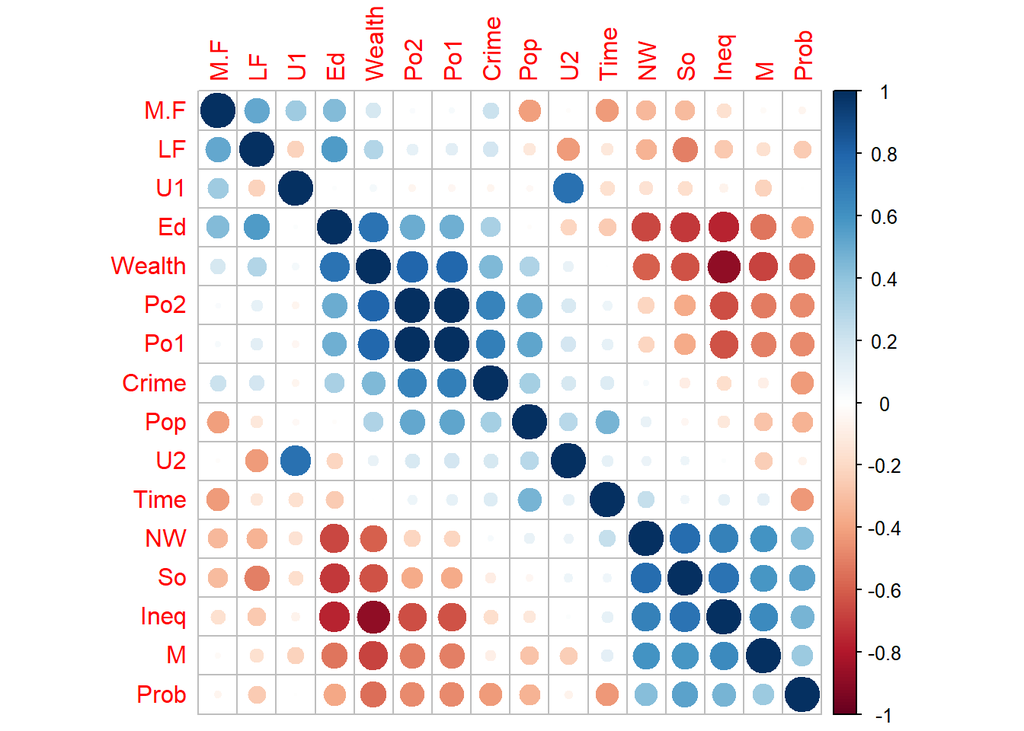

```r
# Draw correlations
# Look at reference 1
crime_data <- cor(uscrime)
corrplot(crime_data, method = "circle", order = 'AOE')
```

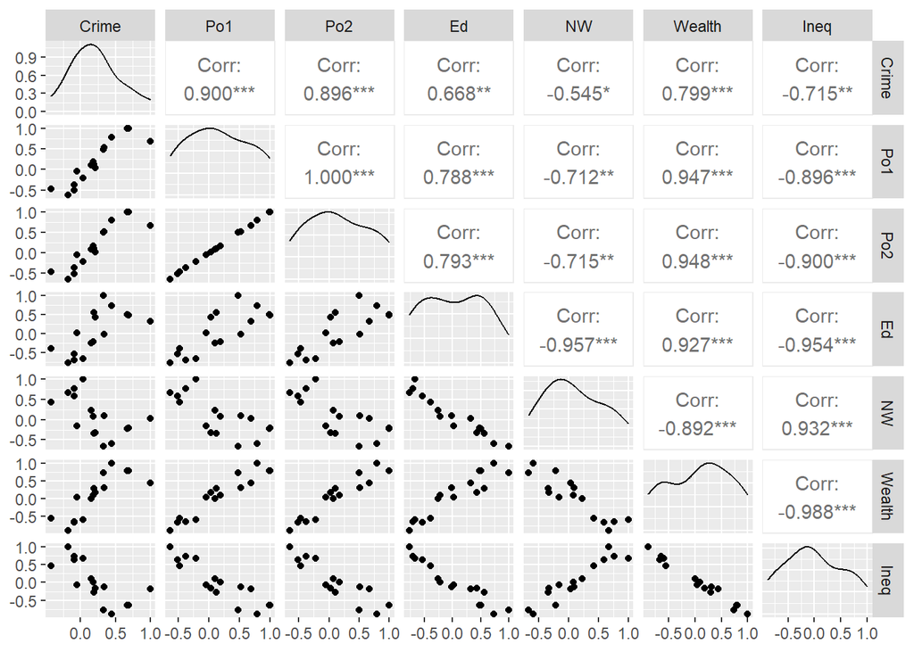

```r
# Examine some of the strongest correlations-
# Look at reference 2
# ggpairs(uscrime, columns = c("Ed", "Ineq", "Po1")) # Choosing These Parameters Based On My Hw 5 Results
ggpairs(crime_data, columns = c('Crime', 'Po1', 'Po2', 'Ed', 'NW', 'Wealth', 'Ineq'))
```

```r
ggpairs
```

[output not shown]

[output cut: 25 more lines]

[output not shown]

Performing PCA, summarizing the results, extracting the eigenvectors, and visualizing the variance explained by each principal component in a scree plot.

```r
# PCA
PCA = prcomp(uscrime[,1:15], scale. = TRUE)
summary(PCA)
```

```
## Importance of components:
##                           PC1    PC2    PC3     PC4     PC5     PC6     PC7
## Standard deviation     2.4534 1.6739 1.4160 1.07806 0.97893 0.74377 0.56729
## Proportion of Variance 0.4013 0.1868 0.1337 0.07748 0.06389 0.03688 0.02145
## Cumulative Proportion  0.4013 0.5880 0.7217 0.79920 0.86308 0.89996 0.92142
##                            PC8     PC9    PC10    PC11    PC12    PC13   PC14
## Standard deviation     0.55444 0.48493 0.44708 0.41915 0.35804 0.26333 0.2418
## Proportion of Variance 0.02049 0.01568 0.01333 0.01171 0.00855 0.00462 0.0039
## Cumulative Proportion  0.94191 0.95759 0.97091 0.98263 0.99117 0.99579 0.9997
##                           PC15
## Standard deviation     0.06793
## Proportion of Variance 0.00031
## Cumulative Proportion  1.00000
```

```r
# Eigenvector Matrix
PCA$rotation
```

```
##                PC1         PC2           PC3         PC4         PC5
## M      -0.30371194  0.06280357  0.1724199946 -0.02035537 -0.35832737
## So     -0.33088129 -0.15837219  0.0155433104  0.29247181 -0.12061130
## Ed      0.33962148  0.21461152  0.0677396249  0.07974375 -0.02442839
## Po1     0.30863412 -0.26981761  0.0506458161  0.33325059 -0.23527680
## Po2     0.31099285 -0.26396300  0.0530651173  0.35192809 -0.20473383
## LF      0.17617757  0.31943042  0.2715301768 -0.14326529 -0.39407588
## M.F     0.11638221  0.39434428 -0.2031621598  0.01048029 -0.57877443
## Pop     0.11307836 -0.46723456  0.0770210971 -0.03210513 -0.08317034
## NW     -0.29358647 -0.22801119  0.0788156621  0.23925971 -0.36079387
## U1      0.04050137  0.00807439 -0.6590290980 -0.18279096 -0.13136873
## U2      0.01812228 -0.27971336 -0.5785006293 -0.06889312 -0.13499487
## Wealth  0.37970331 -0.07718862  0.0100647664  0.11781752  0.01167683
## Ineq   -0.36579778 -0.02752240 -0.0002944563 -0.08066612 -0.21672823
## Prob   -0.25888661  0.15831708 -0.1176726436  0.49303389  0.16562829
## Time   -0.02062867 -0.38014836  0.2235664632 -0.54059002 -0.14764767
##                 PC6         PC7         PC8         PC9        PC10        PC11
## M      -0.449132706 -0.15707378 -0.55367691  0.15474793 -0.01443093  0.39446657
## So     -0.100500743  0.19649727  0.22734157 -0.65599872  0.06141452  0.23397868
## Ed     -0.008571367 -0.23943629 -0.14644678 -0.44326978  0.51887452 -0.11821954
## Po1    -0.095776709  0.08011735  0.04613156  0.19425472 -0.14320978 -0.13042001
## Po2    -0.119524780  0.09518288  0.03168720  0.19512072 -0.05929780 -0.13885912
## LF      0.504234275 -0.15931612  0.25513777  0.14393498  0.03077073  0.38532827
## M.F    -0.074501901  0.15548197 -0.05507254 -0.24378252 -0.35323357 -0.28029732
## Pop     0.547098563  0.09046187 -0.59078221 -0.20244830 -0.03970718  0.05849643
## NW      0.051219538 -0.31154195  0.20432828  0.18984178  0.49201966 -0.20695666
## U1      0.017385981 -0.17354115 -0.20206312  0.02069349  0.22765278 -0.17857891
## U2      0.048155286 -0.07526787  0.24369650  0.05576010 -0.04750100  0.47021842
## Wealth -0.154683104 -0.14859424  0.08630649 -0.23196695 -0.11219383  0.31955631
## Ineq    0.272027031  0.37483032  0.07184018 -0.02494384 -0.01390576 -0.18278697
## Prob    0.283535996 -0.56159383 -0.08598908 -0.05306898 -0.42530006 -0.08978385
## Time   -0.148203050 -0.44199877  0.19507812 -0.23551363 -0.29264326 -0.26363121
##               PC12        PC13        PC14          PC15
## M       0.16580189  0.05142365  0.04901705 -0.0051398012
## So     -0.05753357  0.29368483 -0.29364512 -0.0084369230
## Ed      0.47786536 -0.19441949  0.03964277  0.0280052040
## Po1     0.22611207  0.18592255 -0.09490151  0.6894155129
## Po2     0.19088461  0.13454940 -0.08259642 -0.7200270100
## LF      0.02705134  0.27742957 -0.15385625 -0.0336823193
## M.F    -0.23925913 -0.31624667 -0.04125321 -0.0097922075
## Pop    -0.18350385 -0.12651689 -0.05326383 -0.0001496323
## NW     -0.36671707 -0.22901695  0.13227774  0.0370783671
## U1     -0.09314897  0.59039450 -0.02335942 -0.0111359325
## U2      0.28440496 -0.43292853 -0.03985736 -0.0073618948
## Wealth -0.32172821  0.14077972  0.70031840  0.0025685109
## Ineq    0.43762828  0.12181090  0.59279037 -0.0177570357
## Prob    0.15567100  0.03547596  0.04761011 -0.0293376260
## Time    0.13536989  0.05738113 -0.04488401 -0.0376754405
```

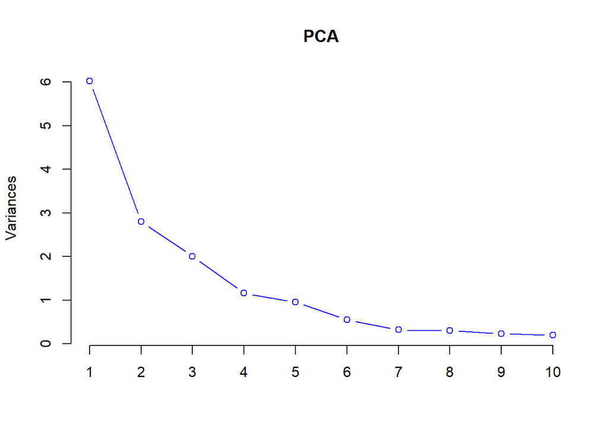

```r
# Use the first 4 PCs
screeplot(PCA, type = "lines", col = "blue")
```

Variance is the square of stdev

```r
# Calculate variances and proportion of variances
variance <- PCA$sdev^2
variance
```

```
##  [1] 6.018952657 2.801847026 2.004944334 1.162207801 0.958298972 0.553193900
##  [7] 0.321818687 0.307401270 0.235155292 0.199880931 0.175685403 0.128190107
## [13] 0.069341691 0.058467765 0.004614165
```

```r
# Plot the proportion of variances from PCA
propvvariance <- variance / sum(variance)
propvvariance
```

```
##  [1] 0.401263510 0.186789802 0.133662956 0.077480520 0.063886598 0.036879593
##  [7] 0.021454579 0.020493418 0.015677019 0.013325395 0.011712360 0.008546007
## [13] 0.004622779 0.003897851 0.000307611
```

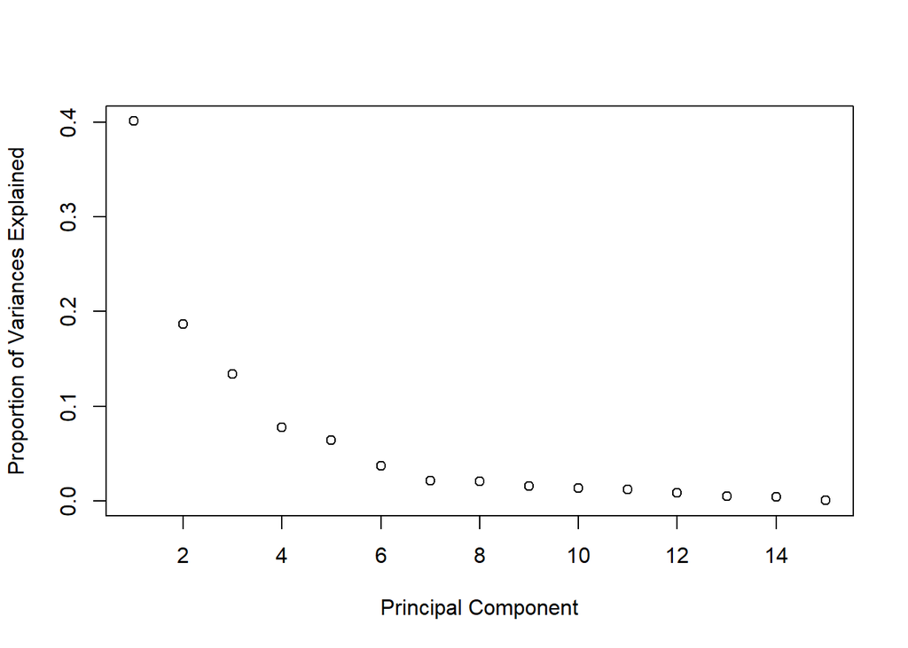

```r
plot(propvvariance, xlab = 'Principal Component', ylab = 'Proportion of Variances Explained')
```

```r
# Plot the cumulative sum proportion of variances from PCA
cumsum_propvvariance <- cumsum(propvvariance)
cumsum_propvvariance
```

```
##  [1] 0.4012635 0.5880533 0.7217163 0.7991968 0.8630834 0.8999630 0.9214176
##  [8] 0.9419110 0.9575880 0.9709134 0.9826258 0.9911718 0.9957945 0.9996924
## [15] 1.0000000
```

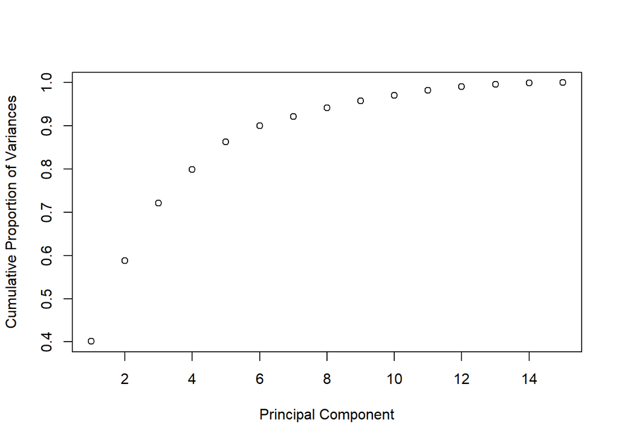

```r
plot(cumsum_propvvariance, xlab = 'Principal Component', ylab = 'Cumulative Proportion of Variances')
```

PCA using prcomp

```r
## all from the TA
# Get the documentation on the `prcomp` function
?prcomp
```

```
## starting httpd help server ... done
```

```r
# Select the first 4 principal components from the transformed data matrix `PCA$x` and assign to `pcs`
pcs <- PCA$x[,1:4]

# Display the attributes of the `PCA$x` object, which contains the transformed data
attributes(PCA$x)
```

```
## $dim
## [1] 47 15
##
## $dimnames
## $dimnames[[1]]
## NULL
##
## $dimnames[[2]]
##  [1] "PC1"  "PC2"  "PC3"  "PC4"  "PC5"  "PC6"  "PC7"  "PC8"  "PC9"  "PC10"
## [11] "PC11" "PC12" "PC13" "PC14" "PC15"
```

```r
# Print the `pcs` object, which contains the first 4 principal components of the transformed data
pcs
```

```
##              PC1         PC2         PC3         PC4
##  [1,] -4.1992835 -1.09383120 -1.11907395  0.67178115
##  [2,]  1.1726630  0.67701360 -0.05244634 -0.08350709
##  [3,] -4.1737248  0.27677501 -0.37107658  0.37793995
##  [4,]  3.8349617 -2.57690596  0.22793998  0.38262331
##  [5,]  1.8392999  1.33098564  1.27882805  0.71814305
##  [6,]  2.9072336 -0.33054213  0.53288181  1.22140635
##  [7,]  0.2457752 -0.07362562 -0.90742064  1.13685873
##  [8,] -0.1301330 -1.35985577  0.59753132  1.44045387
##  [9,] -3.6103169 -0.68621008  1.28372246  0.55171150
## [10,]  1.1672376  3.03207033  0.37984502 -0.28887026
## [11,]  2.5384879 -2.66771358  1.54424656 -0.87671210
## [12,]  1.0065920 -0.06044849  1.18861346 -1.31261964
## [13,]  0.5161143  0.97485189  1.83351610 -1.59117618
## [14,]  0.4265556  1.85044812  1.02893477 -0.07789173
```

[output cut: 33 more lines]

```r
# Compute and display the covariance matrix of the transformed data `PCA$x`
cov(PCA$x)
```

```
##                PC1           PC2           PC3           PC4           PC5
## PC1   6.018953e+00 -1.098127e-15 -1.544752e-16  3.693830e-16  1.865063e-16
## PC2  -1.098127e-15  2.801847e+00  9.788366e-16  2.342961e-16  9.570724e-16
## PC3  -1.544752e-16  9.788366e-16  2.004944e+00  2.001072e-16  2.600435e-16
## PC4   3.693830e-16  2.342961e-16  2.001072e-16  1.162208e+00  1.333804e-17
## PC5   1.865063e-16  9.570724e-16  2.600435e-16  1.333804e-17  9.582990e-01
## PC6   2.879511e-16  6.154262e-17 -7.190865e-16 -1.718133e-16 -3.009062e-16
## PC7   1.627240e-16  4.240998e-16 -1.923180e-16  3.133954e-16  1.247445e-16
## PC8   1.152276e-15 -5.242942e-16 -3.370596e-16 -6.500971e-17  1.211072e-16
## PC9   1.126604e-15  4.433633e-16 -5.413940e-18  2.688967e-16 -4.532466e-17
## PC10 -2.072922e-16 -2.854120e-16  1.611829e-16  1.638547e-16  1.139697e-16
## PC11 -7.864484e-16  4.422602e-16  1.030251e-16  2.364312e-16  4.765422e-17
## PC12  4.040111e-16 -5.014590e-16 -1.069742e-16  1.373123e-16  5.958954e-17
## PC13 -2.131860e-16  1.285027e-16 -1.473578e-16  4.878262e-17  5.836425e-18
## PC14  4.636968e-16  2.651287e-16 -9.411935e-17 -1.756033e-16  3.617936e-18
## PC15 -4.177944e-16  7.093788e-16 -5.313080e-16 -1.893503e-16 -3.238465e-16
##                PC6           PC7           PC8           PC9          PC10
## PC1   2.879511e-16  1.627240e-16  1.152276e-15  1.126604e-15 -2.072922e-16
## PC2   6.154262e-17  4.240998e-16 -5.242942e-16  4.433633e-16 -2.854120e-16
## PC3  -7.190865e-16 -1.923180e-16 -3.370596e-16 -5.413940e-18  1.611829e-16
## PC4  -1.718133e-16  3.133954e-16 -6.500971e-17  2.688967e-16  1.638547e-16
## PC5  -3.009062e-16  1.247445e-16  1.211072e-16 -4.532466e-17  1.139697e-16
## PC6   5.531939e-01  1.444318e-16 -1.656222e-16  1.342535e-16 -5.587899e-17
## PC7   1.444318e-16  3.218187e-01  2.026634e-16 -1.724479e-16 -1.108387e-16
## PC8  -1.656222e-16  2.026634e-16  3.074013e-01  1.402558e-16 -4.379013e-17
## PC9   1.342535e-16 -1.724479e-16  1.402558e-16  2.351553e-01 -2.231368e-16
## PC10 -5.587899e-17 -1.108387e-16 -4.379013e-17 -2.231368e-16  1.998809e-01
## PC11 -1.118805e-16  2.867243e-18 -3.630722e-17  2.908814e-17 -5.216228e-18
## PC12 -1.598629e-16  4.157458e-17  2.490658e-17  6.072440e-17  7.513374e-17
## PC13  9.446981e-17  4.193918e-18  4.885288e-17 -5.371662e-18  3.302827e-17
## PC14  1.205486e-16  5.842075e-17  1.072506e-17  8.072195e-17  5.964485e-17
## PC15 -3.273878e-17  6.632968e-18  3.272132e-17  8.500337e-17 -1.068804e-16
##               PC11          PC12          PC13          PC14          PC15
## PC1  -7.864484e-16  4.040111e-16 -2.131860e-16  4.636968e-16 -4.177944e-16
## PC2   4.422602e-16 -5.014590e-16  1.285027e-16  2.651287e-16  7.093788e-16
## PC3   1.030251e-16 -1.069742e-16 -1.473578e-16 -9.411935e-17 -5.313080e-16
## PC4   2.364312e-16  1.373123e-16  4.878262e-17 -1.756033e-16 -1.893503e-16
## PC5   4.765422e-17  5.958954e-17  5.836425e-18  3.617936e-18 -3.238465e-16
## PC6  -1.118805e-16 -1.598629e-16  9.446981e-17  1.205486e-16 -3.273878e-17
## PC7   2.867243e-18  4.157458e-17  4.193918e-18  5.842075e-17  6.632968e-18
## PC8  -3.630722e-17  2.490658e-17  4.885288e-17  1.072506e-17  3.272132e-17
## PC9   2.908814e-17  6.072440e-17 -5.371662e-18  8.072195e-17  8.500337e-17
## PC10 -5.216228e-18  7.513374e-17  3.302827e-17  5.964485e-17 -1.068804e-16
## PC11  1.756854e-01  7.286497e-17  4.852983e-17 -5.965616e-18  2.151294e-17
## PC12  7.286497e-17  1.281901e-01  1.633553e-17  2.984866e-17 -8.215483e-17
## PC13  4.852983e-17  1.633553e-17  6.934169e-02 -2.230481e-17 -3.796144e-17
## PC14 -5.965616e-18  2.984866e-17 -2.230481e-17  5.846777e-02  1.200577e-17
## PC15  2.151294e-17 -8.215483e-17 -3.796144e-17  1.200577e-17  4.614165e-03
```

```r
# Create a diagonal matrix from the variances (which are the squares of the standard deviations) of the principal components
diag(PCA$sdev^2)
```

```
##           [,1]     [,2]     [,3]     [,4]     [,5]      [,6]      [,7]
##  [1,] 6.018953 0.000000 0.000000 0.000000 0.000000 0.0000000 0.0000000
##  [2,] 0.000000 2.801847 0.000000 0.000000 0.000000 0.0000000 0.0000000
##  [3,] 0.000000 0.000000 2.004944 0.000000 0.000000 0.0000000 0.0000000
##  [4,] 0.000000 0.000000 0.000000 1.162208 0.000000 0.0000000 0.0000000
##  [5,] 0.000000 0.000000 0.000000 0.000000 0.958299 0.0000000 0.0000000
##  [6,] 0.000000 0.000000 0.000000 0.000000 0.000000 0.5531939 0.0000000
##  [7,] 0.000000 0.000000 0.000000 0.000000 0.000000 0.0000000 0.3218187
##  [8,] 0.000000 0.000000 0.000000 0.000000 0.000000 0.0000000 0.0000000
##  [9,] 0.000000 0.000000 0.000000 0.000000 0.000000 0.0000000 0.0000000
## [10,] 0.000000 0.000000 0.000000 0.000000 0.000000 0.0000000 0.0000000
## [11,] 0.000000 0.000000 0.000000 0.000000 0.000000 0.0000000 0.0000000
## [12,] 0.000000 0.000000 0.000000 0.000000 0.000000 0.0000000 0.0000000
## [13,] 0.000000 0.000000 0.000000 0.000000 0.000000 0.0000000 0.0000000
## [14,] 0.000000 0.000000 0.000000 0.000000 0.000000 0.0000000 0.0000000
```

[output cut: 33 more lines]

```r
# Print the transformed data matrix `PCA$x`
PCA$x
```

```
##              PC1         PC2         PC3         PC4          PC5         PC6
##  [1,] -4.1992835 -1.09383120 -1.11907395  0.67178115  0.055283376  0.30733835
##  [2,]  1.1726630  0.67701360 -0.05244634 -0.08350709 -1.173199821 -0.58323731
##  [3,] -4.1737248  0.27677501 -0.37107658  0.37793995  0.541345246  0.71872230
##  [4,]  3.8349617 -2.57690596  0.22793998  0.38262331 -1.644746496  0.72948841
##  [5,]  1.8392999  1.33098564  1.27882805  0.71814305  0.041590320 -0.39409015
##  [6,]  2.9072336 -0.33054213  0.53288181  1.22140635  1.374360960 -0.69225131
##  [7,]  0.2457752 -0.07362562 -0.90742064  1.13685873  0.718644387 -0.93107472
##  [8,] -0.1301330 -1.35985577  0.59753132  1.44045387 -0.222781388  0.04912052
##  [9,] -3.6103169 -0.68621008  1.28372246  0.55171150 -0.324292990  0.12683417
## [10,]  1.1672376  3.03207033  0.37984502 -0.28887026 -0.646056610  0.33130781
## [11,]  2.5384879 -2.66771358  1.54424656 -0.87671210 -0.324083561  0.44365740
## [12,]  1.0065920 -0.06044849  1.18861346 -1.31261964  0.358087724  0.25696957
## [13,]  0.5161143  0.97485189  1.83351610 -1.59117618  0.599881946  1.04761756
## [14,]  0.4265556  1.85044812  1.02893477 -0.07789173  0.741887592  0.61569775
```

[output cut: 129 more lines]

```r
# Print the `pcs` object again, which contains the first 4 principal components of the transformed data
pcs
```

```
##              PC1         PC2         PC3         PC4
##  [1,] -4.1992835 -1.09383120 -1.11907395  0.67178115
##  [2,]  1.1726630  0.67701360 -0.05244634 -0.08350709
##  [3,] -4.1737248  0.27677501 -0.37107658  0.37793995
##  [4,]  3.8349617 -2.57690596  0.22793998  0.38262331
##  [5,]  1.8392999  1.33098564  1.27882805  0.71814305
##  [6,]  2.9072336 -0.33054213  0.53288181  1.22140635
##  [7,]  0.2457752 -0.07362562 -0.90742064  1.13685873
##  [8,] -0.1301330 -1.35985577  0.59753132  1.44045387
##  [9,] -3.6103169 -0.68621008  1.28372246  0.55171150
## [10,]  1.1672376  3.03207033  0.37984502 -0.28887026
## [11,]  2.5384879 -2.66771358  1.54424656 -0.87671210
## [12,]  1.0065920 -0.06044849  1.18861346 -1.31261964
## [13,]  0.5161143  0.97485189  1.83351610 -1.59117618
## [14,]  0.4265556  1.85044812  1.02893477 -0.07789173
```

[output cut: 33 more lines]

```r
# Calculate the correlation matrix of the transformed data `PCA$x`
correlation <- cor(PCA$x)

# Print the correlation matrix
correlation
```

```
##                PC1           PC2           PC3           PC4           PC5
## PC1   1.000000e+00 -2.674053e-16 -4.446797e-17  1.396608e-16  7.765736e-17
## PC2  -2.674053e-16  1.000000e+00  4.129874e-16  1.298377e-16  5.840796e-16
## PC3  -4.446797e-17  4.129874e-16  1.000000e+00  1.310900e-16  1.876050e-16
## PC4   1.396608e-16  1.298377e-16  1.310900e-16  1.000000e+00  1.263862e-17
## PC5   7.765736e-17  5.840796e-16  1.876050e-16  1.263862e-17  1.000000e+00
## PC6   1.578046e-16  4.943278e-17 -6.827965e-16 -2.142774e-16 -4.132776e-16
## PC7   1.169191e-16  4.466221e-16 -2.394215e-16  5.124425e-16  2.246288e-16
## PC8   8.471166e-16 -5.649370e-16 -4.293413e-16 -1.087636e-16  2.231344e-16
## PC9   9.469639e-16  5.462106e-16 -7.884695e-18  5.143589e-16 -9.547874e-17
## PC10 -1.889891e-16 -3.813856e-16  2.546139e-16  3.399627e-16  2.604073e-16
## PC11 -7.647896e-16  6.303588e-16  1.735898e-16  5.232329e-16  1.161403e-16
## PC12  4.599447e-16 -8.367313e-16 -2.110088e-16  3.557463e-16  1.700170e-16
## PC13 -3.299901e-16  2.915364e-16 -3.952071e-16  1.718407e-16  2.264119e-17
## PC14  7.816555e-16  6.550527e-16 -2.748967e-16 -6.736474e-16  1.528453e-17
## PC15 -2.507007e-15  6.238920e-15 -5.523936e-15 -2.585697e-15 -4.870147e-15
##                PC6           PC7           PC8           PC9          PC10
## PC1   1.578046e-16  1.169191e-16  8.471166e-16  9.469639e-16 -1.889891e-16
## PC2   4.943278e-17  4.466221e-16 -5.649370e-16  5.462106e-16 -3.813856e-16
## PC3  -6.827965e-16 -2.394215e-16 -4.293413e-16 -7.884695e-18  2.546139e-16
## PC4  -2.142774e-16  5.124425e-16 -1.087636e-16  5.143589e-16  3.399627e-16
## PC5  -4.132776e-16  2.246288e-16  2.231344e-16 -9.547874e-17  2.604073e-16
## PC6   1.000000e+00  3.423091e-16 -4.016308e-16  3.722286e-16 -1.680444e-16
## PC7   3.423091e-16  1.000000e+00  6.443426e-16 -6.268662e-16 -4.370188e-16
## PC8  -4.016308e-16  6.443426e-16  1.000000e+00  5.216636e-16 -1.766598e-16
## PC9   3.722286e-16 -6.268662e-16  5.216636e-16  1.000000e+00 -1.029220e-15
## PC10 -1.680444e-16 -4.370188e-16 -1.766598e-16 -1.029220e-15  1.000000e+00
## PC11 -3.588790e-16  1.205844e-17 -1.562328e-16  1.431103e-16 -2.783576e-17
## PC12 -6.003186e-16  2.046892e-16  1.254683e-16  3.497507e-16  4.693773e-16
## PC13  4.823443e-16  2.807483e-17  3.346110e-16 -4.206628e-17  2.805453e-16
## PC14  6.702936e-16  4.258957e-16  7.999974e-17  6.884240e-16  5.517331e-16
## PC15 -6.480034e-16  1.721297e-16  8.688234e-16  2.580549e-15 -3.519377e-15
##               PC11          PC12          PC13          PC14          PC15
## PC1  -7.647896e-16  4.599447e-16 -3.299901e-16  7.816555e-16 -2.507007e-15
## PC2   6.303588e-16 -8.367313e-16  2.915364e-16  6.550527e-16  6.238920e-15
## PC3   1.735898e-16 -2.110088e-16 -3.952071e-16 -2.748967e-16 -5.523936e-15
## PC4   5.232329e-16  3.557463e-16  1.718407e-16 -6.736474e-16 -2.585697e-15
## PC5   1.161403e-16  1.700170e-16  2.264119e-17  1.528453e-17 -4.870147e-15
## PC6  -3.588790e-16 -6.003186e-16  4.823443e-16  6.702936e-16 -6.480034e-16
## PC7   1.205844e-17  2.046892e-16  2.807483e-17  4.258957e-16  1.721297e-16
## PC8  -1.562328e-16  1.254683e-16  3.346110e-16  7.999974e-17  8.688234e-16
## PC9   1.431103e-16  3.497507e-16 -4.206628e-17  6.884240e-16  2.580549e-15
## PC10 -2.783576e-17  4.693773e-16  2.805453e-16  5.517331e-16 -3.519377e-15
## PC11  1.000000e+00  4.855385e-16  4.396871e-16 -5.886122e-17  7.555887e-16
## PC12  4.855385e-16  1.000000e+00  1.732642e-16  3.447779e-16 -3.377997e-15
## PC13  4.396871e-16  1.732642e-16  1.000000e+00 -3.503023e-16 -2.122262e-15
## PC14 -5.886122e-17  3.447779e-16 -3.503023e-16  1.000000e+00  7.309460e-16
## PC15  7.555887e-16 -3.377997e-15 -2.122262e-15  7.309460e-16  1.000000e+00
```